# Risk Factor Analysis

## Outcome Variable

**Outcome Variable:** ever_stunted

## Predictor Variables

**Intervention Variable:** exclfeed36

**Adjustment Set:**

- arm
- sex
- brthmon
- W_mage
- meducyrs
- feducyrs
- hhwealth_quart
- hfoodsec
- W_mhtcm
- W_mwtkg
- W_mbmi
- vagbrth
- W_gagebrth
- W_birthwt
- W_birthlen
- W_nrooms
- W_nchldlt5
- month
- W_parity
- impfloor
- impsan
- safeh20
- delta_W_mage
- delta_meducyrs
- delta_feducyrs
- delta_hhwealth_quart
- delta_hfoodsec
- delta_W_mhtcm
- delta_W_mwtkg
- delta_W_mbmi
- delta_vagbrth
- delta_W_gagebrth
- delta_W_birthwt
- delta_W_birthlen
- delta_W_nrooms
- delta_W_nchldlt5
- delta_month
- delta_W_parity
- delta_impfloor
- delta_impsan
- delta_safeh20

## Stratifying Variables

The analysis was stratified on these variable(s):

- agecat
- studyid
- country

## Data Summary

| agecat | studyid | country | exclfeed36 | ever_stunted | n_cell | n |
| --- | --- | --- | --- | --- | --- | --- |
| 0-24 months (no birth st.) | CMC-V-BCS-2002 | INDIA | 1 | 0 | 1 | 6 |
| 0-24 months (no birth st.) | CMC-V-BCS-2002 | INDIA | 1 | 1 | 5 | 6 |
| 0-24 months (no birth st.) | CMC-V-BCS-2002 | INDIA | 0 | 0 | 0 | 6 |
| 0-24 months (no birth st.) | CMC-V-BCS-2002 | INDIA | 0 | 1 | 0 | 6 |
| 0-24 months (no birth st.) | EE | PAKISTAN | 1 | 0 | 0 | 6 |
| 0-24 months (no birth st.) | EE | PAKISTAN | 1 | 1 | 2 | 6 |
| 0-24 months (no birth st.) | EE | PAKISTAN | 0 | 0 | 2 | 6 |
| 0-24 months (no birth st.) | EE | PAKISTAN | 0 | 1 | 2 | 6 |
| 0-24 months (no birth st.) | GMS-Nepal | NEPAL | 1 | 0 | 132 | 443 |
| 0-24 months (no birth st.) | GMS-Nepal | NEPAL | 1 | 1 | 225 | 443 |
| 0-24 months (no birth st.) | GMS-Nepal | NEPAL | 0 | 0 | 22 | 443 |
| 0-24 months (no birth st.) | GMS-Nepal | NEPAL | 0 | 1 | 64 | 443 |
| 0-24 months (no birth st.) | IRC | INDIA | 1 | 0 | 0 | 3 |
| 0-24 months (no birth st.) | IRC | INDIA | 1 | 1 | 0 | 3 |
| 0-24 months (no birth st.) | IRC | INDIA | 0 | 0 | 1 | 3 |
| 0-24 months (no birth st.) | IRC | INDIA | 0 | 1 | 2 | 3 |
| 0-24 months (no birth st.) | JiVitA-3 | BANGLADESH | 1 | 0 | 4970 | 8764 |
| 0-24 months (no birth st.) | JiVitA-3 | BANGLADESH | 1 | 1 | 1853 | 8764 |
| 0-24 months (no birth st.) | JiVitA-3 | BANGLADESH | 0 | 0 | 1441 | 8764 |
| 0-24 months (no birth st.) | JiVitA-3 | BANGLADESH | 0 | 1 | 500 | 8764 |
| 0-24 months (no birth st.) | JiVitA-4 | BANGLADESH | 1 | 0 | 1495 | 3285 |
| 0-24 months (no birth st.) | JiVitA-4 | BANGLADESH | 1 | 1 | 1083 | 3285 |
| 0-24 months (no birth st.) | JiVitA-4 | BANGLADESH | 0 | 0 | 396 | 3285 |
| 0-24 months (no birth st.) | JiVitA-4 | BANGLADESH | 0 | 1 | 311 | 3285 |
| 0-24 months (no birth st.) | Keneba | GAMBIA | 1 | 0 | 285 | 1798 |
| 0-24 months (no birth st.) | Keneba | GAMBIA | 1 | 1 | 286 | 1798 |
| 0-24 months (no birth st.) | Keneba | GAMBIA | 0 | 0 | 544 | 1798 |
| 0-24 months (no birth st.) | Keneba | GAMBIA | 0 | 1 | 683 | 1798 |
| 0-24 months (no birth st.) | LCNI-5 | MALAWI | 1 | 0 | 18 | 175 |
| 0-24 months (no birth st.) | LCNI-5 | MALAWI | 1 | 1 | 12 | 175 |

[output cut: 106 more lines]

The following strata were considered:

- agecat: 0-24 months (no birth st.), studyid: CMC-V-BCS-2002, country: INDIA
- agecat: 0-24 months (no birth st.), studyid: EE, country: PAKISTAN
- agecat: 0-24 months (no birth st.), studyid: GMS-Nepal, country: NEPAL
- agecat: 0-24 months (no birth st.), studyid: IRC, country: INDIA
- agecat: 0-24 months (no birth st.), studyid: JiVitA-3, country: BANGLADESH
- agecat: 0-24 months (no birth st.), studyid: JiVitA-4, country: BANGLADESH
- agecat: 0-24 months (no birth st.), studyid: Keneba, country: GAMBIA
- agecat: 0-24 months (no birth st.), studyid: LCNI-5, country: MALAWI
- agecat: 0-24 months (no birth st.), studyid: MAL-ED, country: BANGLADESH
- agecat: 0-24 months (no birth st.), studyid: MAL-ED, country: BRAZIL
- agecat: 0-24 months (no birth st.), studyid: MAL-ED, country: INDIA
- agecat: 0-24 months (no birth st.), studyid: MAL-ED, country: NEPAL
- agecat: 0-24 months (no birth st.), studyid: MAL-ED, country: PERU
- agecat: 0-24 months (no birth st.), studyid: MAL-ED, country: SOUTH AFRICA
- agecat: 0-24 months (no birth st.), studyid: MAL-ED, country: TANZANIA, UNITED REPUBLIC OF
- agecat: 0-24 months (no birth st.), studyid: PROVIDE, country: BANGLADESH
- agecat: 0-24 months (no birth st.), studyid: SAS-FoodSuppl, country: INDIA
- agecat: 0-6 months (no birth st.), studyid: CMC-V-BCS-2002, country: INDIA
- agecat: 0-6 months (no birth st.), studyid: EE, country: PAKISTAN
- agecat: 0-6 months (no birth st.), studyid: GMS-Nepal, country: NEPAL
- agecat: 0-6 months (no birth st.), studyid: IRC, country: INDIA
- agecat: 0-6 months (no birth st.), studyid: JiVitA-3, country: BANGLADESH
- agecat: 0-6 months (no birth st.), studyid: JiVitA-4, country: BANGLADESH
- agecat: 0-6 months (no birth st.), studyid: Keneba, country: GAMBIA
- agecat: 0-6 months (no birth st.), studyid: LCNI-5, country: MALAWI
- agecat: 0-6 months (no birth st.), studyid: MAL-ED, country: BANGLADESH
- agecat: 0-6 months (no birth st.), studyid: MAL-ED, country: BRAZIL
- agecat: 0-6 months (no birth st.), studyid: MAL-ED, country: INDIA
- agecat: 0-6 months (no birth st.), studyid: MAL-ED, country: NEPAL
- agecat: 0-6 months (no birth st.), studyid: MAL-ED, country: PERU
- agecat: 0-6 months (no birth st.), studyid: MAL-ED, country: SOUTH AFRICA
- agecat: 0-6 months (no birth st.), studyid: MAL-ED, country: TANZANIA, UNITED REPUBLIC OF
- agecat: 0-6 months (no birth st.), studyid: PROVIDE, country: BANGLADESH
- agecat: 0-6 months (no birth st.), studyid: SAS-FoodSuppl, country: INDIA

### Dropped Strata

Some strata were dropped due to rare outcomes:

- agecat: 0-24 months (no birth st.), studyid: CMC-V-BCS-2002, country: INDIA
- agecat: 0-24 months (no birth st.), studyid: EE, country: PAKISTAN
- agecat: 0-24 months (no birth st.), studyid: IRC, country: INDIA
- agecat: 0-24 months (no birth st.), studyid: MAL-ED, country: BRAZIL
- agecat: 0-24 months (no birth st.), studyid: MAL-ED, country: INDIA
- agecat: 0-24 months (no birth st.), studyid: MAL-ED, country: NEPAL
- agecat: 0-24 months (no birth st.), studyid: MAL-ED, country: PERU
- agecat: 0-24 months (no birth st.), studyid: MAL-ED, country: SOUTH AFRICA
- agecat: 0-24 months (no birth st.), studyid: MAL-ED, country: TANZANIA, UNITED REPUBLIC OF
- agecat: 0-24 months (no birth st.), studyid: SAS-FoodSuppl, country: INDIA
- agecat: 0-6 months (no birth st.), studyid: CMC-V-BCS-2002, country: INDIA
- agecat: 0-6 months (no birth st.), studyid: EE, country: PAKISTAN
- agecat: 0-6 months (no birth st.), studyid: IRC, country: INDIA
- agecat: 0-6 months (no birth st.), studyid: LCNI-5, country: MALAWI
- agecat: 0-6 months (no birth st.), studyid: MAL-ED, country: BRAZIL
- agecat: 0-6 months (no birth st.), studyid: MAL-ED, country: INDIA
- agecat: 0-6 months (no birth st.), studyid: MAL-ED, country: NEPAL
- agecat: 0-6 months (no birth st.), studyid: MAL-ED, country: PERU
- agecat: 0-6 months (no birth st.), studyid: MAL-ED, country: SOUTH AFRICA
- agecat: 0-6 months (no birth st.), studyid: MAL-ED, country: TANZANIA, UNITED REPUBLIC OF
- agecat: 0-6 months (no birth st.), studyid: SAS-FoodSuppl, country: INDIA

## Methods Detail

We're interested in the causal parameters $E[Y_a]$ for all values of $a \in \mathcal{A}$. These parameters represent the mean outcome if, possibly contrary to fact, we intervened to set all units to have $A=a$. Under the randomization and positivity assumptions, these are identified by the statistical parameters $\psi_a=E_W[E_{Y|A,W}(Y|A=a,W)]$. In addition, we're interested in the mean of $Y$, $E[Y]$ under no intervention (the observed mean). We will estimate these parameters by using SuperLearner to fit the relevant likelihood factors -- $E_{Y|A,W}(Y|A=a,W)$ and $p(A=a|W)$, and then updating our likelihood fit using a joint TMLE.

For unadjusted analyses ($W=\{\}$), initial likelihoods were estimated using Lrnr_glm to estimate the simple $E(Y|A)$ and Lrnr_mean to estimate $p(A)$. For adjusted analyses, a small library containing Lrnr_glmnet, Lrnr_xgboost, and Lrnr_mean was used.

Having estimated these parameters, we will then use the delta method to estimate relative risks and attributable risks relative to a prespecified baseline level of $A$.

# Results Detail

## Results Plots

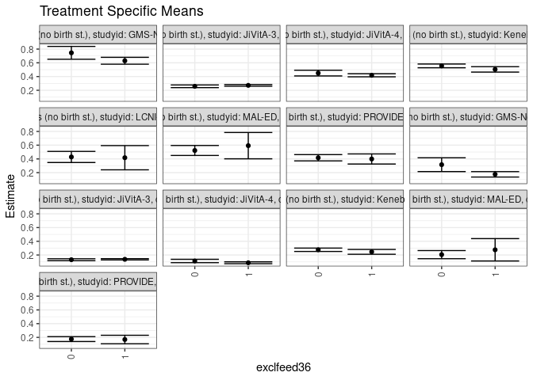

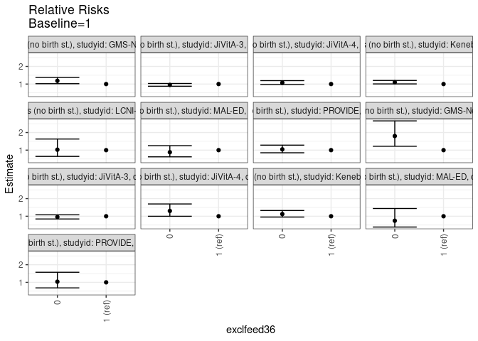

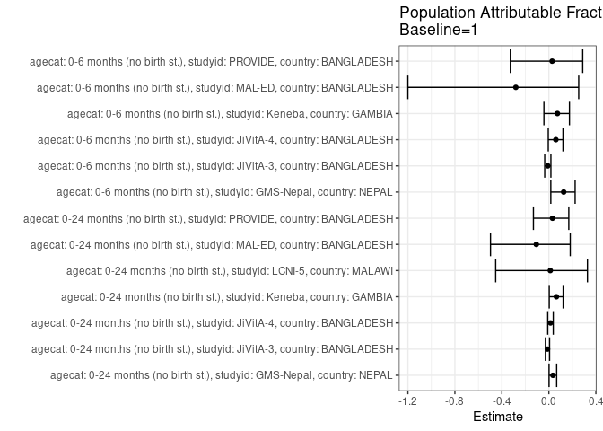

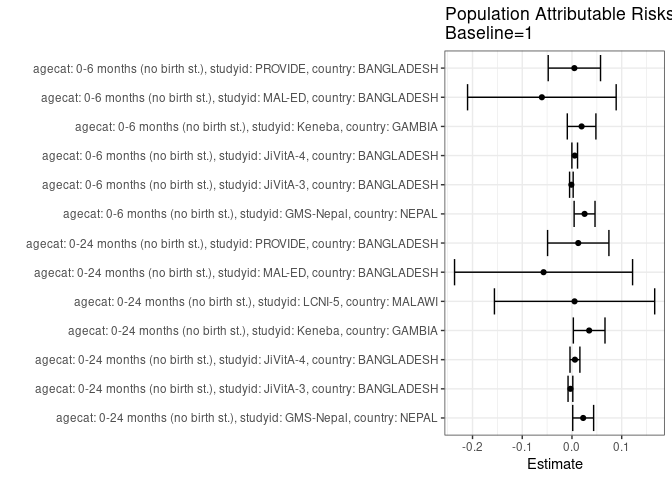

## Results Table

### Parameter: TSM

| agecat | studyid | country | intervention_level | baseline_level | estimate | ci_lower | ci_upper |
| --- | --- | --- | --- | --- | --- | --- | --- |
| 0-24 months (no birth st.) | GMS-Nepal | NEPAL | 1 | NA | 0.6298392 | 0.5796493 | 0.6800292 |
| 0-24 months (no birth st.) | GMS-Nepal | NEPAL | 0 | NA | 0.7454821 | 0.6519844 | 0.8389799 |
| 0-24 months (no birth st.) | JiVitA-3 | BANGLADESH | 1 | NA | 0.2715968 | 0.2593120 | 0.2838816 |
| 0-24 months (no birth st.) | JiVitA-3 | BANGLADESH | 0 | NA | 0.2581165 | 0.2388566 | 0.2773764 |
| 0-24 months (no birth st.) | JiVitA-4 | BANGLADESH | 1 | NA | 0.4183718 | 0.3957999 | 0.4409438 |
| 0-24 months (no birth st.) | JiVitA-4 | BANGLADESH | 0 | NA | 0.4502609 | 0.4086167 | 0.4919052 |
| 0-24 months (no birth st.) | Keneba | GAMBIA | 1 | NA | 0.5043555 | 0.4649258 | 0.5437853 |
| 0-24 months (no birth st.) | Keneba | GAMBIA | 0 | NA | 0.5552387 | 0.5280057 | 0.5824717 |
| 0-24 months (no birth st.) | LCNI-5 | MALAWI | 1 | NA | 0.4176650 | 0.2413533 | 0.5939767 |
| 0-24 months (no birth st.) | LCNI-5 | MALAWI | 0 | NA | 0.4285160 | 0.3476791 | 0.5093530 |
| 0-24 months (no birth st.) | MAL-ED | BANGLADESH | 1 | NA | 0.5930269 | 0.4013667 | 0.7846871 |
| 0-24 months (no birth st.) | MAL-ED | BANGLADESH | 0 | NA | 0.5227875 | 0.4500437 | 0.5955313 |
| 0-24 months (no birth st.) | PROVIDE | BANGLADESH | 1 | NA | 0.3988472 | 0.3252920 | 0.4724024 |
| 0-24 months (no birth st.) | PROVIDE | BANGLADESH | 0 | NA | 0.4167334 | 0.3708939 | 0.4625729 |
| 0-6 months (no birth st.) | GMS-Nepal | NEPAL | 1 | NA | 0.1755672 | 0.1358659 | 0.2152686 |
| 0-6 months (no birth st.) | GMS-Nepal | NEPAL | 0 | NA | 0.3160613 | 0.2155366 | 0.4165860 |
| 0-6 months (no birth st.) | JiVitA-3 | BANGLADESH | 1 | NA | 0.1374865 | 0.1283631 | 0.1466099 |
| 0-6 months (no birth st.) | JiVitA-3 | BANGLADESH | 0 | NA | 0.1313839 | 0.1172730 | 0.1454948 |
| 0-6 months (no birth st.) | JiVitA-4 | BANGLADESH | 1 | NA | 0.0869167 | 0.0732174 | 0.1006161 |
| 0-6 months (no birth st.) | JiVitA-4 | BANGLADESH | 0 | NA | 0.1131327 | 0.0886704 | 0.1375949 |
| 0-6 months (no birth st.) | Keneba | GAMBIA | 1 | NA | 0.2459374 | 0.2110814 | 0.2807934 |
| 0-6 months (no birth st.) | Keneba | GAMBIA | 0 | NA | 0.2764170 | 0.2517654 | 0.3010685 |
| 0-6 months (no birth st.) | MAL-ED | BANGLADESH | 1 | NA | 0.2758621 | 0.1128022 | 0.4389220 |
| 0-6 months (no birth st.) | MAL-ED | BANGLADESH | 0 | NA | 0.2055556 | 0.1463790 | 0.2647321 |
| 0-6 months (no birth st.) | PROVIDE | BANGLADESH | 1 | NA | 0.1687946 | 0.1070548 | 0.2305345 |
| 0-6 months (no birth st.) | PROVIDE | BANGLADESH | 0 | NA | 0.1750283 | 0.1393568 | 0.2106998 |

### Parameter: E(Y)

| agecat | studyid | country | intervention_level | baseline_level | estimate | ci_lower | ci_upper |
| --- | --- | --- | --- | --- | --- | --- | --- |
| 0-24 months (no birth st.) | GMS-Nepal | NEPAL | NA | NA | 0.6523702 | 0.6079743 | 0.6967661 |
| 0-24 months (no birth st.) | JiVitA-3 | BANGLADESH | NA | NA | 0.2684847 | 0.2575491 | 0.2794203 |
| 0-24 months (no birth st.) | JiVitA-4 | BANGLADESH | NA | NA | 0.4243531 | 0.4041458 | 0.4445604 |
| 0-24 months (no birth st.) | Keneba | GAMBIA | NA | NA | 0.5389321 | 0.5158847 | 0.5619796 |
| 0-24 months (no birth st.) | LCNI-5 | MALAWI | NA | NA | 0.4228571 | 0.3494545 | 0.4962598 |
| 0-24 months (no birth st.) | MAL-ED | BANGLADESH | NA | NA | 0.5358852 | 0.4681109 | 0.6036595 |
| 0-24 months (no birth st.) | PROVIDE | BANGLADESH | NA | NA | 0.4114583 | 0.3712361 | 0.4516805 |
| 0-6 months (no birth st.) | GMS-Nepal | NEPAL | NA | NA | 0.2009029 | 0.1635496 | 0.2382563 |
| 0-6 months (no birth st.) | JiVitA-3 | BANGLADESH | NA | NA | 0.1362858 | 0.1283472 | 0.1442245 |
| 0-6 months (no birth st.) | JiVitA-4 | BANGLADESH | NA | NA | 0.0924163 | 0.0803439 | 0.1044888 |
| 0-6 months (no birth st.) | Keneba | GAMBIA | NA | NA | 0.2652948 | 0.2448823 | 0.2857072 |
| 0-6 months (no birth st.) | MAL-ED | BANGLADESH | NA | NA | 0.2153110 | 0.1594513 | 0.2711707 |
| 0-6 months (no birth st.) | PROVIDE | BANGLADESH | NA | NA | 0.1736111 | 0.1426515 | 0.2045707 |

### Parameter: RR

| agecat | studyid | country | intervention_level | baseline_level | estimate | ci_lower | ci_upper |
| --- | --- | --- | --- | --- | --- | --- | --- |
| 0-24 months (no birth st.) | GMS-Nepal | NEPAL | 1 | 1 | 1.0000000 | 1.0000000 | 1.000000 |
| 0-24 months (no birth st.) | GMS-Nepal | NEPAL | 0 | 1 | 1.1836070 | 1.0200246 | 1.373423 |
| 0-24 months (no birth st.) | JiVitA-3 | BANGLADESH | 1 | 1 | 1.0000000 | 1.0000000 | 1.000000 |
| 0-24 months (no birth st.) | JiVitA-3 | BANGLADESH | 0 | 1 | 0.9503666 | 0.8750444 | 1.032172 |
| 0-24 months (no birth st.) | JiVitA-4 | BANGLADESH | 1 | 1 | 1.0000000 | 1.0000000 | 1.000000 |
| 0-24 months (no birth st.) | JiVitA-4 | BANGLADESH | 0 | 1 | 1.0762219 | 0.9698265 | 1.194290 |
| 0-24 months (no birth st.) | Keneba | GAMBIA | 1 | 1 | 1.0000000 | 1.0000000 | 1.000000 |
| 0-24 months (no birth st.) | Keneba | GAMBIA | 0 | 1 | 1.1008874 | 1.0064716 | 1.204160 |
| 0-24 months (no birth st.) | LCNI-5 | MALAWI | 1 | 1 | 1.0000000 | 1.0000000 | 1.000000 |
| 0-24 months (no birth st.) | LCNI-5 | MALAWI | 0 | 1 | 1.0259802 | 0.6456861 | 1.630259 |
| 0-24 months (no birth st.) | MAL-ED | BANGLADESH | 1 | 1 | 1.0000000 | 1.0000000 | 1.000000 |
| 0-24 months (no birth st.) | MAL-ED | BANGLADESH | 0 | 1 | 0.8815579 | 0.6198395 | 1.253783 |
| 0-24 months (no birth st.) | PROVIDE | BANGLADESH | 1 | 1 | 1.0000000 | 1.0000000 | 1.000000 |
| 0-24 months (no birth st.) | PROVIDE | BANGLADESH | 0 | 1 | 1.0448448 | 0.8499704 | 1.284398 |
| 0-6 months (no birth st.) | GMS-Nepal | NEPAL | 1 | 1 | 1.0000000 | 1.0000000 | 1.000000 |
| 0-6 months (no birth st.) | GMS-Nepal | NEPAL | 0 | 1 | 1.8002291 | 1.2184566 | 2.659779 |
| 0-6 months (no birth st.) | JiVitA-3 | BANGLADESH | 1 | 1 | 1.0000000 | 1.0000000 | 1.000000 |
| 0-6 months (no birth st.) | JiVitA-3 | BANGLADESH | 0 | 1 | 0.9556133 | 0.8453458 | 1.080264 |
| 0-6 months (no birth st.) | JiVitA-4 | BANGLADESH | 1 | 1 | 1.0000000 | 1.0000000 | 1.000000 |
| 0-6 months (no birth st.) | JiVitA-4 | BANGLADESH | 0 | 1 | 1.3016219 | 0.9986231 | 1.696556 |
| 0-6 months (no birth st.) | Keneba | GAMBIA | 1 | 1 | 1.0000000 | 1.0000000 | 1.000000 |
| 0-6 months (no birth st.) | Keneba | GAMBIA | 0 | 1 | 1.1239322 | 0.9539140 | 1.324253 |
| 0-6 months (no birth st.) | MAL-ED | BANGLADESH | 1 | 1 | 1.0000000 | 1.0000000 | 1.000000 |
| 0-6 months (no birth st.) | MAL-ED | BANGLADESH | 0 | 1 | 0.7451389 | 0.3861012 | 1.438048 |
| 0-6 months (no birth st.) | PROVIDE | BANGLADESH | 1 | 1 | 1.0000000 | 1.0000000 | 1.000000 |
| 0-6 months (no birth st.) | PROVIDE | BANGLADESH | 0 | 1 | 1.0369306 | 0.6837748 | 1.572484 |

### Parameter: PAR

| agecat | studyid | country | intervention_level | baseline_level | estimate | ci_lower | ci_upper |
| --- | --- | --- | --- | --- | --- | --- | --- |
| 0-24 months (no birth st.) | GMS-Nepal | NEPAL | 1 | NA | 0.0225310 | 0.0015242 | 0.0435377 |
| 0-24 months (no birth st.) | JiVitA-3 | BANGLADESH | 1 | NA | -0.0031121 | -0.0078900 | 0.0016659 |
| 0-24 months (no birth st.) | JiVitA-4 | BANGLADESH | 1 | NA | 0.0059813 | -0.0039745 | 0.0159371 |
| 0-24 months (no birth st.) | Keneba | GAMBIA | 1 | NA | 0.0345766 | 0.0027497 | 0.0664035 |
| 0-24 months (no birth st.) | LCNI-5 | MALAWI | 1 | NA | 0.0051921 | -0.1559501 | 0.1663343 |
| 0-24 months (no birth st.) | MAL-ED | BANGLADESH | 1 | NA | -0.0571417 | -0.2361584 | 0.1218750 |
| 0-24 months (no birth st.) | PROVIDE | BANGLADESH | 1 | NA | 0.0126112 | -0.0490646 | 0.0742870 |
| 0-6 months (no birth st.) | GMS-Nepal | NEPAL | 1 | NA | 0.0253357 | 0.0043330 | 0.0463384 |
| 0-6 months (no birth st.) | JiVitA-3 | BANGLADESH | 1 | NA | -0.0012007 | -0.0048028 | 0.0024014 |
| 0-6 months (no birth st.) | JiVitA-4 | BANGLADESH | 1 | NA | 0.0054996 | -0.0001883 | 0.0111876 |
| 0-6 months (no birth st.) | Keneba | GAMBIA | 1 | NA | 0.0193574 | -0.0094083 | 0.0481231 |
| 0-6 months (no birth st.) | MAL-ED | BANGLADESH | 1 | NA | -0.0605511 | -0.2099840 | 0.0888819 |
| 0-6 months (no birth st.) | PROVIDE | BANGLADESH | 1 | NA | 0.0048165 | -0.0477878 | 0.0574208 |

### Parameter: PAF

| agecat | studyid | country | intervention_level | baseline_level | estimate | ci_lower | ci_upper |
| --- | --- | --- | --- | --- | --- | --- | --- |
| 0-24 months (no birth st.) | GMS-Nepal | NEPAL | 1 | NA | 0.0345371 | 0.0015664 | 0.0664190 |
| 0-24 months (no birth st.) | JiVitA-3 | BANGLADESH | 1 | NA | -0.0115912 | -0.0295118 | 0.0060174 |
| 0-24 months (no birth st.) | JiVitA-4 | BANGLADESH | 1 | NA | 0.0140951 | -0.0096607 | 0.0372919 |
| 0-24 months (no birth st.) | Keneba | GAMBIA | 1 | NA | 0.0641576 | 0.0031101 | 0.1214667 |
| 0-24 months (no birth st.) | LCNI-5 | MALAWI | 1 | NA | 0.0122787 | -0.4527288 | 0.3284408 |
| 0-24 months (no birth st.) | MAL-ED | BANGLADESH | 1 | NA | -0.1066305 | -0.4968881 | 0.1818819 |
| 0-24 months (no birth st.) | PROVIDE | BANGLADESH | 1 | NA | 0.0306499 | -0.1314833 | 0.1695507 |
| 0-6 months (no birth st.) | GMS-Nepal | NEPAL | 1 | NA | 0.1261091 | 0.0164838 | 0.2235153 |
| 0-6 months (no birth st.) | JiVitA-3 | BANGLADESH | 1 | NA | -0.0088101 | -0.0355279 | 0.0172183 |
| 0-6 months (no birth st.) | JiVitA-4 | BANGLADESH | 1 | NA | 0.0595093 | -0.0051908 | 0.1200449 |
| 0-6 months (no birth st.) | Keneba | GAMBIA | 1 | NA | 0.0729655 | -0.0420660 | 0.1752990 |
| 0-6 months (no birth st.) | MAL-ED | BANGLADESH | 1 | NA | -0.2812261 | -1.2003633 | 0.2539685 |
| 0-6 months (no birth st.) | PROVIDE | BANGLADESH | 1 | NA | 0.0277429 | -0.3280183 | 0.2881997 |